# Home Price Prediction in Miami

Shubham Annadate & Aayush Dua

# 1 Introduction

The aim of this project is to build a good predictive model of home prices for Miami, Florida. Purchasing a house is an important decision in a person’s life and requires a lot of thought and research. We care about building a better predictive model of home prices so that it can help people who plan to purchase a house in Miami, know the price of a house in today’s market. At the same time, this predictive model can help in providing homeowners in Miami, an independent and unbiased assessment of what their home prices might be worth in present. This helps potential buyers/ home owners in planning their finances and investments well.

Many factors go into play while predicting home prices in general. We have to research what these factors are and what is the underlying context behind these factors. Along with that, while building predictive models we make assumptions that ignore non-quantifiable factors such consumer confidence and sudden factors such as COVID outbreak. Coupling all of this together makes this exercise difficult.

In this project, we identify three major types of features that we believe will have a huge impact on predicting the home prices in Miami, Florida. These include:

- **Internal Characteristics**: Includes internal features of a house such as house size, whether it has pool or not, number of beds etc.
- **Amenities/ Public Services**: Includes features such as distance to amenities and public services that Miami has to offer from a house. For example, distance to bars, pubs, schools, hospitals, police stations etc.
- **Spatial Structure**: Includes features that are geographically relevant to a house. For example, driving distance to a beach from house, and significance of which neighborhood the house lies in.

Our final model does a respectable job in predicting home prices for almost all houses except for some luxury homes giving a mean absolute error of around $200K for houses prices less than $5m.

# 2 Setup

Before proceeding with the analysis, we undertake some initial setups which involve importing required libraries and writing helper functions.

```r
library(tidyverse)
library(sf)
library(spdep)
library(caret)
library(ckanr)
library(FNN)
library(grid)
library(gridExtra)
library(ggcorrplot)
library(osmdata)
library(geosphere)
library(kableExtra)
library(tidycensus)
library(scales)
library(mapboxapi)
library(leaflet)
library(sjPlot)
library(sjmisc)
library(sjlabelled)
library(stargazer)
library(pander)

mapTheme <- function(base_size = 12) {
  theme(
    text = element_text( color = "black"),
    plot.title = element_text(size = 14,colour = "black"),
    plot.subtitle=element_text(face="italic"),
    plot.caption=element_text(hjust=0),
    axis.ticks = element_blank(),
    panel.background = element_blank(),axis.title = element_blank(),
    axis.text = element_blank(),
    axis.title.x = element_blank(),
    axis.title.y = element_blank(),
    panel.grid.minor = element_blank(),
    panel.border = element_rect(colour = "black", fill=NA, size=2)
  )
}

plotTheme <- function(base_size = 12) {
  theme(
    text = element_text( color = "black"),
    plot.title = element_text(size = 14,colour = "black"),
    plot.subtitle = element_text(face="italic"),
    plot.caption = element_text(hjust=0),
    axis.ticks = element_blank(),
    panel.background = element_blank(),
    panel.grid.major = element_line("grey80", size = 0.1),
    panel.grid.minor = element_blank(),
    panel.border = element_rect(colour = "black", fill=NA, size=2),
    strip.background = element_rect(fill = "grey80", color = "white"),
    strip.text = element_text(size=12),
    axis.title = element_text(size=12),
    axis.text = element_text(size=10),
    plot.background = element_blank(),
    legend.background = element_blank(),
    legend.title = element_text(colour = "black", face = "italic"),
    legend.text = element_text(colour = "black", face = "italic"),
    strip.text.x = element_text(size = 14)
  )
}


palette5 <- c("#FA7800","#C48C04","#8FA108","#5AB60C","#25CB10")
palette5 <- c("#25CB10", "#5AB60C", "#8FA108",   "#C48C04", "#FA7800")

qBr <- function(df, variable, rnd) {
  if (missing(rnd)) {
    as.character(quantile(round(df[[variable]],0),
                          c(.01,.2,.4,.6,.8), na.rm=T))
  } else if (rnd == FALSE | rnd == F) {
    as.character(formatC(quantile(df[[variable]]), digits = 3),
                 c(.01,.2,.4,.6,.8), na.rm=T)
  }
}

q5 <- function(variable) {as.factor(ntile(variable, 5))}

nn_function <- function(measureFrom,measureTo,k) {
  measureFrom_Matrix <- as.matrix(measureFrom)
  measureTo_Matrix <- as.matrix(measureTo)
  nn <-
    get.knnx(measureTo, measureFrom, k)$nn.dist
  output <-
    as.data.frame(nn) %>%
    rownames_to_column(var = "thisPoint") %>%
    gather(points, point_distance, V1:ncol(.)) %>%
    arrange(as.numeric(thisPoint)) %>%
    group_by(thisPoint) %>%
    summarize(pointDistance = mean(point_distance)) %>%
    arrange(as.numeric(thisPoint)) %>%
    dplyr::select(-thisPoint) %>%
    pull()

  return(output)
}

st_c <- st_coordinates

############################## HELPER FUNCTIONS ##############################

# Function to extract amenity from a passed string
get_amenity <- function(x){

  amenities <- c("Pool", "Patio", "Fence", "Carport", "Wall", "Dock", "Gazebo", "Elevator",
                 "Enclosure", "Paving", "Jacuzzi", "Tiki Hut", "Tennis Court")

  for(am in amenities){
    if(grepl(am, x, ignore.case = TRUE)){
      return(am)
    }
  }
  ifelse(length(str_trim(x)) > 1, "Other", NA)
}

# Function to get one hot encoded vectors for amenities
get_one_hot_encoded_amneties <- function(x){

  amenities <- c("Pool", "Patio", "Fence", "Carport", "Wall", "Dock", "Gazebo", "Elevator",
                 "Enclosure", "Paving", "Jacuzzi", "Tiki Hut", "Tennis Court")

  oh_amenities <- rep(0, length(amenities))
  names(oh_amenities) <- amenities

  for(n in names(x)){
    if(!is.na(x[n])){
      oh_amenities[x[n]] <- 1
    }
  }
  oh_amenities
}

# Function to extract zone code from ZondCode string
get_zone_code <- function(x) {str_split(x, " ")[[1]][1]}

# Function to get the data of the amenity
get_amenity_data <- function(bbox, key, value, crs, base.osm){

  am_osm_data <- opq(bbox = bbox) %>%
    add_osm_feature(key = key, value = value) %>%
    osmdata_sf()

  points <-
    am_osm_data$osm_points %>%
    .[base.osm,]

  points <- points %>% st_transform(crs=crs)

  points

}

# Function to get the average distance to n nearest amenities
get_n_nn <- function(df, points, n, var_name){

  for(i in 1:n){
    col = paste0(var_name, "_nn", i)
    df[[col]] <- nn_function(st_c(df), st_c(points), i)
  }

  df
}

# Function to get the driving distance from a house to South Beach
get_driving_dist_to_south_beach <- function(prop_addr){

  tryCatch({
    prop_geo_code <- mb_geocode(prop_addr)

    route <- mb_directions(origin = prop_geo_code,
                           destination = "South Beach, MIAMI",
                           profile = "driving")

    route$distance
  }, error = function(cond){
      return(NA)
  })

}
```

# 3 Data

## 3.1 Data Gathering Methodology

For this prediction task, we used data from five sources as described below:

- **Housing Data**: This data was provided to us as part of the analysis. It contains one row per house along with some of its features like living area, number of bedrooms and so on.
- **Neighborhood Data**: This is an open source data which we use to find boundaries of various neighborhoods in the Miami region.
- **Municipality Data**: The neighborhood data discussed above does not contain boundaries for the Miami Beach, hence we rely on the municipal boundaries of the same as a proxy for the neighborhood.
- **OpenStreetMap (OSM) Data**: We use this to get access to interesting geodata like Miami Coastline, and location of amenities like nightclubs, transit stops and so on in the Miami region.
- **Census Data**: We use this data to check the generalizability of the predicitve model we build across race and income groups.

```r
# CRS
crs = st_crs("+proj=lcc +lat_1=41.71666666666667 +lat_2=42.68333333333333 +lat_0=41 +lon_0=-71.5 +x_0=200000 +y_0=750000 +ellps=GRS80 +units=m no_defs")

# Loading the given house data
miami_houses.sf <- st_read("studentsData.geojson") %>%
  st_transform(crs=crs) %>%
  st_centroid() %>%
  mutate(PricePerSq = SalePrice/ActualSqFt)

# Loading neighborhood data and filtering out some not needed neighborhoods
nbhood <- st_read("https://opendata.arcgis.com/datasets/2f54a0cbd67046f2bd100fb735176e6c_0.geojson") %>%
  st_transform(crs=crs) %>%
  select(LABEL) %>%
  rename(nbhood = LABEL) %>%
  filter(!nbhood %in% c("Virginia Key", " ", "Port of Miami", "Watson Island", "Pelican Harbor"))

# Use municipal data to find Miami Beach boundary
miami_beach_boundary <- st_read("https://opendata.arcgis.com/datasets/5ece0745e24b4617a49f2e098df8117f_0.geojson") %>%
  st_transform(crs=crs) %>%
  filter(NAME == 'MIAMI BEACH') %>%
  select(NAME) %>%
  st_union() %>%
  st_sf() %>%
  mutate(nbhood = "Miami Beach")

# Adding Miami Beach to neighborhood data
nbhood <- rbind(nbhood, miami_beach_boundary)

# Correcting for house that lies on two neighborhood boundaries
miami_houses.sf <- miami_houses.sf %>%
  st_join(nbhood) %>%
  mutate(nbhood = ifelse(is.na(nbhood), "Belle Meade", nbhood))

# Loading the base map for Miami
miami.base <-
  st_read("https://opendata.arcgis.com/datasets/5ece0745e24b4617a49f2e098df8117f_0.geojson") %>%
  filter(NAME == "MIAMI BEACH" | NAME == "MIAMI") %>%
  st_transform(crs=crs) %>%
  st_union()
```

## 3.2 Feature Engineering

After collecting the data, we next focused on cleaning some of the existing features in the data and also using the open data sources as described in the above section, to engineering new features of interest that might help us in predicted the house prices. Following we provide a brief idea of the various features we engineered:

```r
################ Feature Engineering with the given set of features ################

# Generating one-hot-encoded vectors for amenities
miami_houses.sf$Amenity1 <- unname(sapply(miami_houses.sf$XF1, get_amenity))
miami_houses.sf$Amenity2 <- unname(sapply(miami_houses.sf$XF2, get_amenity))
miami_houses.sf$Amenity3 <- unname(sapply(miami_houses.sf$XF3, get_amenity))

oh_amenities_df <- st_drop_geometry(miami_houses.sf) %>%
  select(Amenity1, Amenity2, Amenity3) %>%
  apply(1, get_one_hot_encoded_amneties) %>%
  as.matrix() %>%
  t() %>%
  as.data.frame()

# Cleaning the ZoneCode column
# zonecode.clean <- unname(sapply(miami_houses.sf$Zoning, get_zone_code))
# miami_houses.sf$ZoneCode <- zonecode.clean

# Cleaning the Year Build and Effective Year Build column
miami_houses.sf <- miami_houses.sf %>%
  mutate(
    EffectiveYearBuilt.cat = case_when(
      EffectiveYearBuilt < 1960 ~ "Before 1960",
      EffectiveYearBuilt >= 1960 & EffectiveYearBuilt <= 2010 ~ "1960 - 2010",
      EffectiveYearBuilt > 2010 ~ "After 2010"
    )
  )
  # mutate(
  #   YearBuilt.cat = case_when(
  #     YearBuilt < 1990 ~ "Before 1990",
  #     YearBuilt >= 1990 & YearBuilt <= 2010 ~ "1990 - 2010",
  #     YearBuilt > 2010 ~ "After 2010"
  #   )
  # )


# Adding the age of the building
miami_houses.sf <- miami_houses.sf %>%
  mutate(Age = as.numeric(saleYear) - YearBuilt)

################ Engineering new features ################

#################################
##### Distance to Coastline #####
#################################

# Get base map for Miami to use with the OSM data
miami.base.osm <-
  st_read("https://opendata.arcgis.com/datasets/5ece0745e24b4617a49f2e098df8117f_0.geojson") %>%
  filter(NAME == "MIAMI BEACH" | NAME == "MIAMI") %>%
  st_union()

# Generate the bounding box around Miami region we want
xmin = st_bbox(miami.base.osm)[[1]]
ymin = st_bbox(miami.base.osm)[[2]]
xmax = st_bbox(miami.base.osm)[[3]]
ymax = st_bbox(miami.base.osm)[[4]]

bbox <- c(xmin, ymin, xmax, ymax)

#Coastline Data
Coastline<-opq(bbox = bbox) %>%
  add_osm_feature("natural", "coastline") %>%
  osmdata_sf()

# Uncomment below code to calculate shoreline distance
# This takes some time therefore we load and use precomputed values

# miami_houses.sf <-
#   miami_houses.sf %>%
#   mutate(CoastDist=(geosphere::dist2Line(p=st_coordinates(miami_houses.sf %>% st_transform(crs=4326)),
#                                          line=st_coordinates(Coastline$osm_lines)[,1:2])*0.00062137)[,1])

# Load precomputed values
load("CoastDist.RData")
miami_houses.sf$CoastDist <- CoastDist

# Creating categories for distance to shoreline
miami_houses.sf <-
  miami_houses.sf %>%
  mutate(
    CoastDist.cat = ifelse(CoastDist < 0.5, "LT 0.5", "GT 0.5")
  )

#############################
##### Various Amenities #####
#############################

# Eateries
eateries <- get_amenity_data(bbox, 'amenity', c("restaurant", "cafe", "fast_food"), crs, miami.base.osm)
miami_houses.sf <- get_n_nn(miami_houses.sf, eateries, 1, "eateries")

### Nightclub
nightlife <- get_amenity_data(bbox, 'amenity', c("bar", "nightclub", "pub", "casino", "gambling"), crs, miami.base.osm)
miami_houses.sf <- get_n_nn(miami_houses.sf, nightlife, 1, "nightlife")

### Schools
schools <- get_amenity_data(bbox, 'amenity', c("school", "university", "kindergarten","college"), crs, miami.base.osm)
miami_houses.sf <- get_n_nn(miami_houses.sf, schools, 3, "school")

### Police stations
police_stations <- get_amenity_data(bbox, 'amenity', "police", crs, miami.base.osm)
miami_houses.sf <- get_n_nn(miami_houses.sf, police_stations, 1, "police_station")

### Healthcare
healthcare <- get_amenity_data(bbox, 'amenity', c("clinic", "hospital"), crs, miami.base.osm)
miami_houses.sf <- get_n_nn(miami_houses.sf, healthcare, 1, "healthcare")

### Public transport
public_transport <- get_amenity_data(bbox, 'public_transport', c("stop_position"), crs, miami.base.osm)
miami_houses.sf <- get_n_nn(miami_houses.sf, public_transport, 1, "public_transport")

### Supermarket
supermarket <- get_amenity_data(bbox, 'shop', c("supermarket"), crs, miami.base.osm)
miami_houses.sf <- get_n_nn(miami_houses.sf, supermarket, 1, "supermarket")

###########################################
##### Driving Distance to South Beach #####
###########################################

# Get a column for complete house address
miami_houses.sf <- miami_houses.sf %>%
  mutate(prop_comp_addr = paste0(Property.Address, ", ",
                                 Property.City, ", ",
                                 Property.Zip))

# Uncomment the below code to calcuate the driving distance in real-time
# This would take some time hence we use a precomputed one

# miami_beach_dists <- unname(sapply(miami_houses.sf$prop_comp_addr, get_driving_dist_to_south_beach))
# miami_beach_dists[sapply(miami_beach_dists, is.null)] <- mean(unlist(miami_beach_dists), na.rm = TRUE)
# miami_beach_dists <- unlist(miami_beach_dists)

# Load the precomputed driving distance to south beach
load("miami_beach_dists_prop.RData")

# Add column to data
miami_houses.sf$south_beach_drive_dist <- miami_beach_dists

# Create a categorical variable for the driving distance to south beach variable
miami_houses.sf <-
  miami_houses.sf %>%
  mutate(
    south_beach_drive_dist.cat = ifelse(south_beach_drive_dist < 7.5, "LT 7", "GT 7")
  )

##################################
##### Filtering out features #####
##################################

# Selecting out the final features we would use for the analysis
miami_houses_feats.sf <- cbind(miami_houses.sf, oh_amenities_df) %>%
  select(toPredict, SalePrice, saleYear, AdjustedSqFt, LotSize, LivingSqFt, ActualSqFt, Bed, Bath, Stories,
         EffectiveYearBuilt.cat, Pool, Patio, Fence, Carport, Wall, Dock, Gazebo, Elevator,Enclosure,
         Paving, Jacuzzi, Tiki.Hut, Tennis.Court,
         CoastDist, CoastDist.cat,
         eateries_nn1, nightlife_nn1, school_nn1,
         police_station_nn1, healthcare_nn1, public_transport_nn1, supermarket_nn1,
         nbhood,
         south_beach_drive_dist, south_beach_drive_dist.cat,
         Age)
```

## 3.3 Potential Features

Following we present the summary statistics of all the potential features we considered for this analysis grouped by their category (internal characteristics, amenities/public services and spatial structure).

```r
stargazer(st_drop_geometry(miami_houses_feats.sf) %>% select("AdjustedSqFt","LotSize","LivingSqFt","ActualSqFt","Bed","Bath","Stories","Pool","Patio","Fence","Carport","Wall","Dock","Gazebo","Elevator","Enclosure","Paving","Jacuzzi","Tiki.Hut","Tennis.Court","Age"), type = "text",
          title="Descriptive statistics- Internal Characteristics", digits=1,median=TRUE,iqr=FALSE,
          covariate.labels=c("Adjusted Square Feet","Lot Size","Living Square Feet","Actual Square Feet","Number of Beds","Number of Baths","Number of Stories","Presence of Pool","Presence of Patio","Presence of Fence","Presence of Carport","Presence of Wall","Presence of Dock","Presence of Gazebo","Presence of Elevator","Presence of Enclosure","Presence of Paving","Presence of Jacuzzi","Presence of Tikki Hut","Presence of Tennis Court"))
```

```
##
## Descriptive statistics- Internal Characteristics
## ======================================================================================
## Statistic                  N    Mean   St. Dev.  Min  Pctl(25) Median  Pctl(75)  Max
## --------------------------------------------------------------------------------------
## Adjusted Square Feet     3,503 2,082.2 1,426.0   331   1,274    1,690   2,379   18,006
## Lot Size                 3,503 7,657.8 4,401.4  1,250  5,500   6,693.8  8,025   80,664
## Living Square Feet       3,503 2,011.4 1,369.2   288  1,220.5   1,632   2,321   18,006
## Actual Square Feet       3,503 2,367.7 1,732.3   388   1,412    1,884  2,676.5  20,192
## Number of Beds           3,503   3.0     1.1      0      2        3       4       13
## Number of Baths          3,503   2.1     1.3      0      1        2       3       12
## Number of Stories        3,503   1.2     0.4      0      1        1       1       4
## Presence of Pool         3,503   0.3     0.5      0      0        0       1       1
## Presence of Patio        3,503   0.6     0.5      0      0        1       1       1
## Presence of Fence        3,503   0.6     0.5      0      0        1       1       1
## Presence of Carport      3,503   0.1     0.2      0      0        0       0       1
## Presence of Wall         3,503   0.1     0.3      0      0        0       0       1
## Presence of Dock         3,503  0.04     0.2      0      0        0       0       1
## Presence of Gazebo       3,503  0.01     0.1      0      0        0       0       1
## Presence of Elevator     3,503  0.01     0.1      0      0        0       0       1
## Presence of Enclosure    3,503  0.01     0.1      0      0        0       0       1
## Presence of Paving       3,503  0.004    0.1      0      0        0       0       1
## Presence of Jacuzzi      3,503  0.01     0.1      0      0        0       0       1
## Presence of Tikki Hut    3,503  0.003    0.1      0      0        0       0       1
## Presence of Tennis Court 3,503  0.001    0.02     0      0        0       0       1
## Age                      3,503  67.9     22.5    -1      66      72       80     115
## --------------------------------------------------------------------------------------
```

```r
stargazer(st_drop_geometry(miami_houses_feats.sf) %>% select("eateries_nn1","nightlife_nn1","school_nn1","police_station_nn1","healthcare_nn1","public_transport_nn1","supermarket_nn1"), type = "text",
          title="Descriptive statistics- Public Services/Amenities", digits=1,median=TRUE,iqr=FALSE,
          covariate.labels=c("Dist to nearest eatery","Dist to nearest nightlife","Dist to nearest school","Dist to nearest police station","Dist to nearest hospital","Dist to nearest transit stop","Dist to nearest supermarket"))
```

```
##
## Descriptive statistics- Public Services/Amenities
## ============================================================================================
## Statistic                        N    Mean   St. Dev. Min  Pctl(25) Median  Pctl(75)   Max
## --------------------------------------------------------------------------------------------
## Dist to nearest eatery         3,503  788.6   558.7   35.6  374.4    639.3  1,056.4  2,856.6
## Dist to nearest nightlife      3,503 1,564.0  942.2   52.7  945.6   1,362.9 1,967.7  5,984.2
## Dist to nearest school         3,503  388.7   357.1   13.0  191.9    306.5   459.0   2,423.9
## Dist to nearest police station 3,503 1,662.7 1,106.8  13.0  864.0   1,384.7 2,078.8  5,346.6
## Dist to nearest hospital       3,503 1,826.2 1,116.3  28.1 1,081.2  1,652.3 2,262.1  6,391.8
## Dist to nearest transit stop   3,503  682.7   684.2   22.5  210.2    408.5   920.7   3,551.2
## Dist to nearest supermarket    3,503 1,460.0  865.9   83.0  778.4   1,263.1 2,019.2  4,070.0
## --------------------------------------------------------------------------------------------
```

```r
stargazer(st_drop_geometry(miami_houses_feats.sf) %>% select("CoastDist","south_beach_drive_dist"), type = "text",
          title="Descriptive statistics- Public Services/Amenities", digits=1,median=TRUE,iqr=FALSE,
          covariate.labels=c("Distance to Coastline","Driving Distance to Miami South Beach"))
```

```
##
## Descriptive statistics- Public Services/Amenities
## =============================================================================================
## Statistic                               N   Mean St. Dev.  Min  Pctl(25) Median Pctl(75) Max
## ---------------------------------------------------------------------------------------------
## Distance to Coastline                 3,503 1.1    1.3    0.000   0.1     0.5     1.6    5.4
## Driving Distance to Miami South Beach 3,503 13.9   5.2     1.3    10.8    14.7    17.5   25.4
## ---------------------------------------------------------------------------------------------
```

```r
other<- data.frame("Internal Characteristics" = c("Sale Year","Effective Year Built", ""), "Spatial Characteristics" = c("Whether Distance to Coast Line>=0.5 or not", "Whether Driving Distance to South Beach>=7.5 miles or not","Belongs to which Neigborhood"))
other %>% pander("Categorical Variables")
```

Categorical Variables

| Internal.Characteristics | Spatial.Characteristics |
| --- | --- |
| Sale Year | Whether Distance to Coast Line>=0.5 or not |
| Effective Year Built | Whether Driving Distance to South Beach>=7.5 miles or not |
|  | Belongs to which Neigborhood |

## 3.4 Exploring the Data

### 3.4.1 Correlation Matrix

Next we present a correlation matrix (Figure 1) of all the numeric potential features we have till now which can help us in predicting the price of the house. Key takeaways from this plot include:

- Many of the features have high correlation with Sale Price for example, the adjusted square feet of the house, presence of pool and elevator, distance to the coast line and so on.
- Many of the features are correlated among themselves, for example features accounting for the size of the house, the number of bedrooms and bathrooms a house has and so on. We would have to deal with these features to ensure stability in the predictive model we make.
- Some features like presence of wall, enclosure, tikihut and so on are not correlated with the price of the house, and hence we might do away with these features.

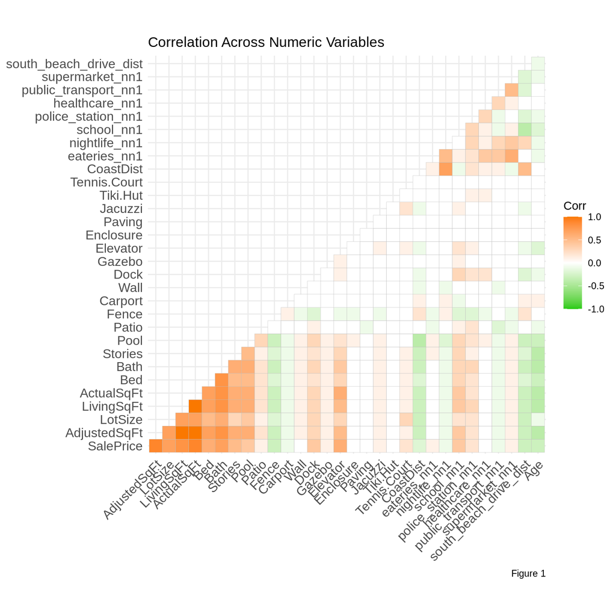

```r
# Filter out the numerical variables
numericVars <-
  select_if(st_drop_geometry(miami_houses_feats.sf), is.numeric) %>% na.omit() %>%
  filter(toPredict == 0) %>%
  select(-toPredict)

# Create a correlation plot
ggcorrplot(
  round(cor(numericVars), 1),
  p.mat = cor_pmat(numericVars),
  colors = c("#25CB10", "white", "#FA7800"),
  type="lower",
  insig = "blank") +
  labs(title = "Correlation Across Numeric Variables",
       caption = "Figure 1")
```

### 3.4.2 Correlation Scatterplots

Following we present home price correlation scatterplots for 4 variables (Figure 2) namely, age of the house, distance to the coast line, distance to nearest nightlife amenity and distance to nearest police station. Key takeaways from this plot include:

- Newer houses tend to have higher prices.
- Houses near the coastline tend to be more costly.
- Houses near nightlife amenities like pubs, bars, and nightclubs tend to be more costly.
- Interestingly, houses near police stations are much cheaper.

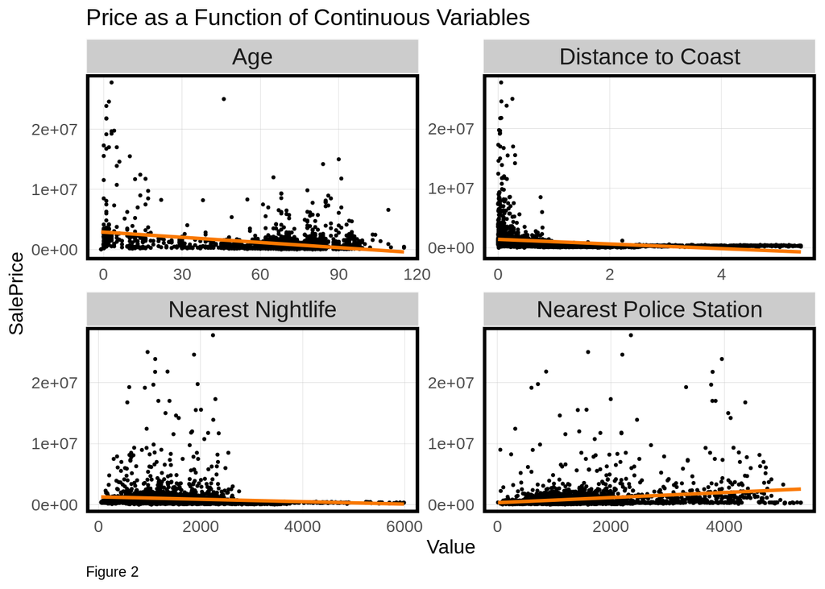

```r
# Correlation Scatterplots
st_drop_geometry(miami_houses_feats.sf) %>%
  filter(toPredict==0) %>%
  dplyr::select(SalePrice, police_station_nn1, Age, nightlife_nn1, CoastDist) %>%
  rename(
    `Nearest Police Station` = police_station_nn1,
    `Age` = Age,
    `Nearest Nightlife` = nightlife_nn1,
    `Distance to Coast` = CoastDist
  ) %>%
  gather(Variable, Value, -SalePrice) %>%
  ggplot(aes(Value, SalePrice)) +
  geom_point(size = .5) + geom_smooth(method = "lm", se=F, colour = "#FA7800") +
  facet_wrap(~Variable, ncol = 2, scales = "free") +
  labs(title = "Price as a Function of Continuous Variables",
       caption = "Figure 2") +
  plotTheme()
```

### 3.4.3 Map of Dependent Variable

Following we present a map of the sale price of the houses (Figure 3). A quick glimpse at the map reveals that houses near to the coastline tend to be priced higher and the prices tend to go down as one goes away from the coastline. This is in consensus with the correlation plot we saw in the above section for the distance to coast variable (Figure 2).

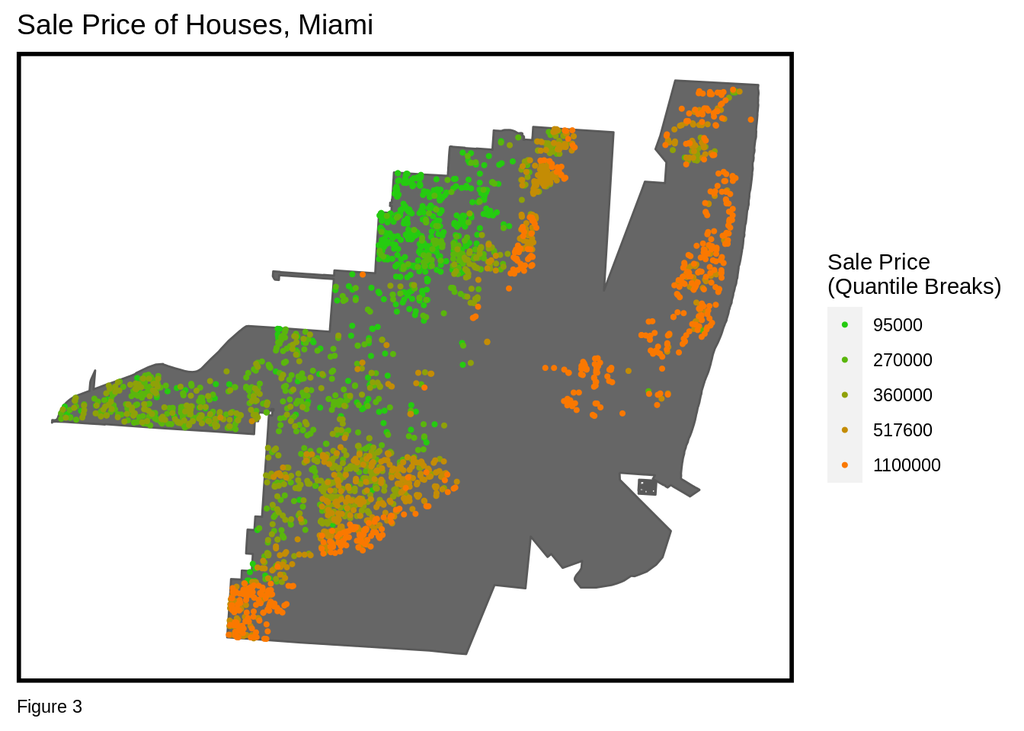

```r
# Map of Sale Price
ggplot() +
  geom_sf(data = miami.base, fill = "grey40") +
  geom_sf(data = miami_houses.sf %>% filter(toPredict == 0), aes(colour = q5(SalePrice)),
          show.legend = "point", size = .75) +
  scale_colour_manual(values = palette5,
                      labels=qBr(miami_houses.sf %>% filter(toPredict == 0),"SalePrice"),
                      name="Sale Price\n(Quantile Breaks)") +
  labs(title="Sale Price of Houses, Miami",
       caption = "Figure 3") +
  mapTheme()
```

### 3.4.4 Map of Independent Variables

Following we map three of the independent variables (Figure 4), namely whether/not the house has a pool, driving distance from a house to the South Beach and nearest distance to a public transport stop. An interesting observation to make here is that the utility of pool is generally associated with those houses that are close to the coastline or lie in the Miami Beach region.

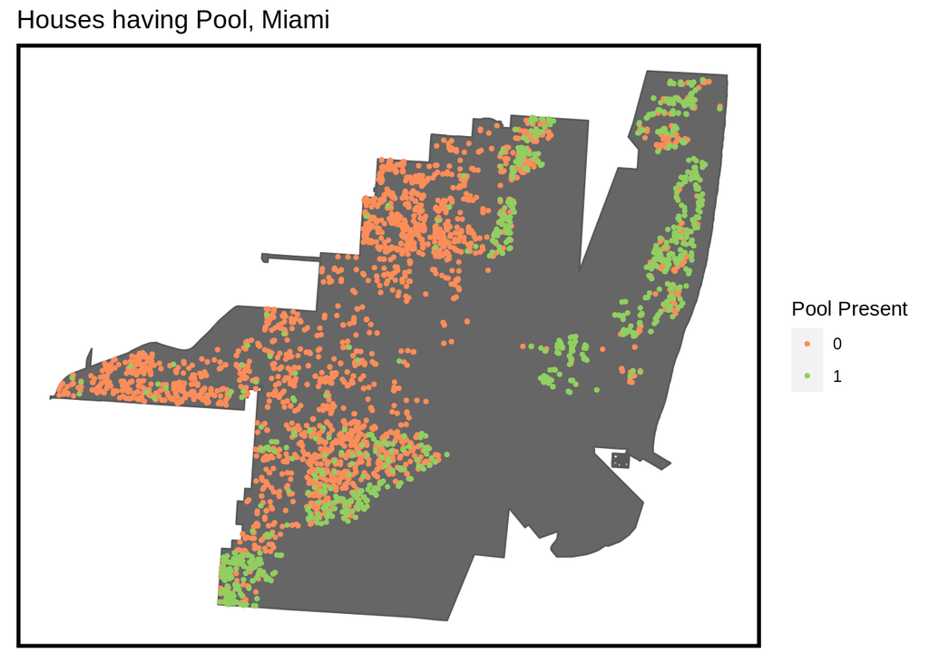

```r
# Map of 3 independent variables

# Plot 1
ggplot() +
  geom_sf(data = miami.base, fill = "grey40") +
  geom_sf(data = miami_houses_feats.sf, aes(color=factor(Pool)),
          show.legend = "point", size = .75) +
  scale_color_manual(values=c("#fc8d59", "#91cf60"))+
  labs(title="Houses having Pool, Miami",
       color = "Pool Present"
       ) +
  mapTheme()
```

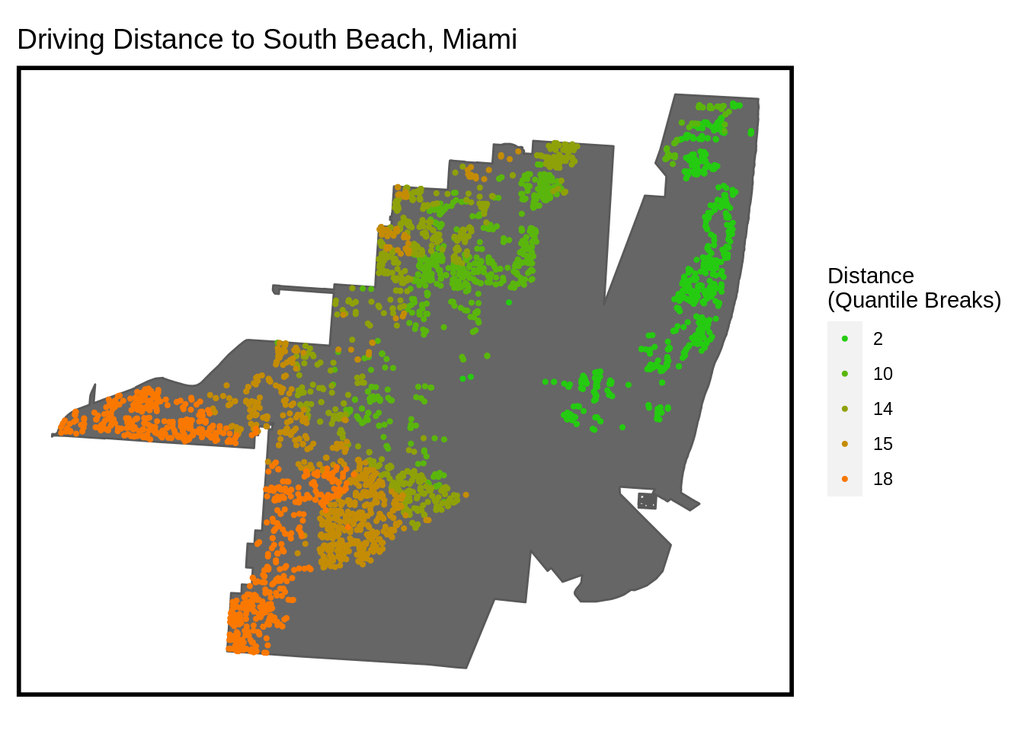

```r
# Plot 2
ggplot() +
  geom_sf(data = miami.base, fill = "grey40") +
  geom_sf(data = miami_houses_feats.sf, aes(colour = q5(south_beach_drive_dist)),
          show.legend = "point", size = .75) +
  scale_colour_manual(values = palette5,
                      labels=qBr(miami_houses_feats.sf,"south_beach_drive_dist"),
                      name="Distance\n(Quantile Breaks)") +
  labs(title="Driving Distance to South Beach, Miami") +
  mapTheme()
```

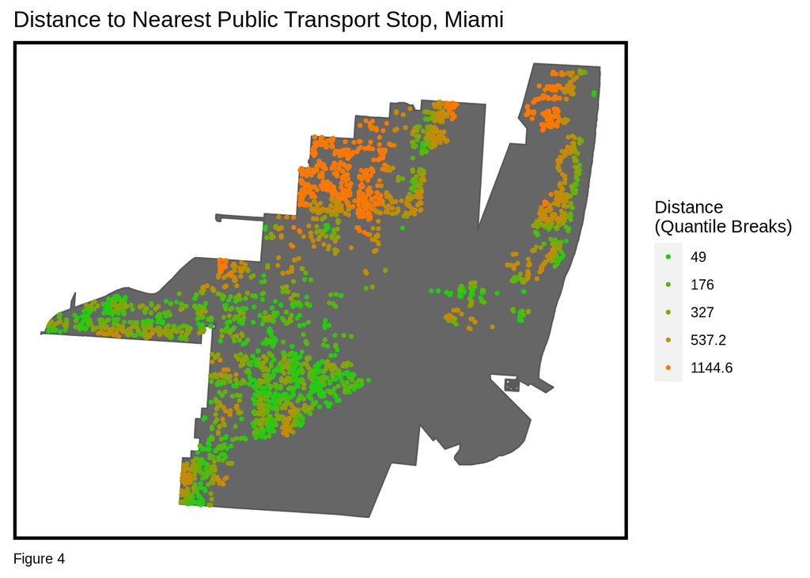

```r
# Plot 3
ggplot() +
  geom_sf(data = miami.base, fill = "grey40") +
  geom_sf(data = miami_houses_feats.sf, aes(colour = q5(public_transport_nn1)),
          show.legend = "point", size = .75) +
  scale_colour_manual(values = palette5,
                      labels=qBr(miami_houses_feats.sf,"public_transport_nn1"),
                      name="Distance\n(Quantile Breaks)") +
  labs(title="Distance to Nearest Public Transport Stop, Miami",
       caption = "Figure 4") +
  mapTheme()
```

# 4 Method

In order to come up with a model for predicting the home prices, we use the following mentioned methodology:

- Given our data, we divide it into two sets, one on which we would build our prediction model and second on which we would test out this model and analyze its performance on unknown data.
- To build the model, we use a simple OLS (Ordinary Least Squares) method, which given a set of features of the house, learns the relationship between these features and the sale price of the house.
- Next, we analyze the errors of our model to check where the model is going wrong and if we are missing some spatial information.
- Lastly, we check whether the model we build is generalizable across neighborhood, race and income groups.

# 5 Results

## 5.1 Summary Results

Following table shows the results after fitting an OLS model for predicting house price. For some of the features that we considered, the results from this can be interpreted as follows:

- An increase of 1 square feet in the adjusted square feet of the house, results in an increase of approximately $282 in sale price.
- Having a pool in the house results in an increase of approximately $150,000 in the sale price.
- Having a house within the Miami Beach neighborhood results in an increase of approximately $380000 in the sale price (realtive to baseline neighborhood).
- Our model, given the set of features, roughly explains 83% of the variation in the sale price of the homes in the training data.

*Note: We drop some of the features that were discussed in the above sections to make the model more stable and improve the fitness and generalizability.*

```r
# Remove features we do not need
miami_houses_feats.sf <- miami_houses_feats.sf %>%
  select(-c(LotSize, LivingSqFt, ActualSqFt, Bath,
            Wall, Gazebo, Paving, Jacuzzi, Tiki.Hut, Tennis.Court, CoastDist, south_beach_drive_dist))

# Set seed for reproducibility
set.seed(2010)

# Separate out data available to building model
miami_test.sf <- miami_houses_feats.sf %>% filter(toPredict == 1) %>% select(-toPredict)
miami_train.sf <- miami_houses_feats.sf %>% filter(toPredict == 0) %>% select(-toPredict)

# Create partition of the available data into training and testing
inTrain <- createDataPartition(
  y = paste(miami_train.sf$saleYear, miami_train.sf$EffectiveYearBuilt.cat,  miami_train.sf$nbhood),
  p = .80, list = FALSE)

miami.training <- miami_train.sf[inTrain,]
miami.test <- miami_train.sf[-inTrain,]

# Remove outliers from the training data
upper_bound <- quantile(miami.training$SalePrice, 0.95)
lower_bound <- quantile(miami.training$SalePrice, 0.05)

to_keep_in_training <- miami.training$SalePrice < upper_bound & miami.training$SalePrice > lower_bound

miami.training <- miami.training[to_keep_in_training,]

# Train OLS model and output trained model parameters and fitness
reg.training <- lm(SalePrice ~ ., data = st_drop_geometry(miami.training))

tab_model(reg.training)
```

|  | SalePrice |  |  |
| --- | --- | --- | --- |
| Predictors | Estimates | CI | p |
| (Intercept) | -191898.63 | -621242.39 – 237445.13 | 0.381 |
| saleYear [2019] | 11050.87 | -10026.76 – 32128.49 | 0.304 |
| saleYear [2020] | 56510.96 | 29422.64 – 83599.28 | **<0.001** |
| AdjustedSqFt | 282.44 | 260.38 – 304.51 | **<0.001** |
| Bed | -12635.47 | -26897.65 – 1626.71 | 0.082 |
| Stories | 19996.91 | -11550.76 – 51544.58 | 0.214 |
| EffectiveYearBuilt.cat [After 2010] | 237810.02 | 181639.00 – 293981.04 | **<0.001** |
| EffectiveYearBuilt.cat [Before 1960] | -50724.40 | -72413.95 – -29034.84 | **<0.001** |
| Pool | 150349.06 | 119535.20 – 181162.92 | **<0.001** |
| Patio | 6562.51 | -14762.69 – 27887.72 | 0.546 |
| Fence | -11250.84 | -33484.79 – 10983.11 | 0.321 |
| Carport | 2357.48 | -37329.06 – 42044.03 | 0.907 |
| Dock | 439774.46 | 355811.52 – 523737.40 | **<0.001** |
| Elevator | 150378.80 | -66961.86 – 367719.46 | 0.175 |
| Enclosure | -82269.90 | -167496.08 – 2956.27 | 0.058 |
| CoastDist.cat [LT 0.5] | 27232.63 | -13419.10 – 67884.36 | 0.189 |
| eateries_nn1 | 22.18 | -23.01 – 67.38 | 0.336 |
| nightlife_nn1 | 20.34 | -4.43 – 45.12 | 0.107 |
| school_nn1 | 49.33 | -0.92 – 99.57 | 0.054 |
| police_station_nn1 | -19.21 | -39.83 – 1.42 | 0.068 |
| healthcare_nn1 | 29.53 | 6.30 – 52.75 | **0.013** |
| public_transport_nn1 | -75.10 | -123.50 – -26.71 | **0.002** |
| supermarket_nn1 | -43.10 | -69.83 – -16.37 | **0.002** |
| nbhood [Allapattah Industrial District] | 108296.90 | -383154.63 – 599748.44 | 0.666 |
| nbhood [Auburndale] | 48360.30 | -381568.60 – 478289.21 | 0.825 |
| nbhood [Bay Heights] | 444518.50 | 6431.29 – 882605.70 | **0.047** |
| nbhood [Baypoint] | 936637.66 | 505786.42 – 1367488.89 | **<0.001** |
| nbhood [Bayside] | 178418.87 | -251073.45 – 607911.19 | 0.415 |
| nbhood [Belle Island] | 720494.90 | 235543.90 – 1205445.90 | **0.004** |

[output cut: 67 more lines]

## 5.2 Performance on Test Set

To get a sense of how good our fitted model is, we evaluate it on the testing set. From Table 1 it can be seen that our model make an absolute error of around $438000 (Mean absolute percent error-MAPE of 35%), which is considerably high given that the average sale price of a home in the test set is around $1.1 million.

```r
# Find median price
median_training_sale_price <- median(miami.training$SalePrice)

# Find predictions and errors on test set
miami.test <- miami.test %>%
  mutate(SalePrice.Predict = predict(reg.training, miami.test),
         SalePrice.Predict = ifelse(SalePrice.Predict < 0, median_training_sale_price, SalePrice.Predict),
         SalePrice.Error = SalePrice.Predict - SalePrice,
         SalePrice.AbsError = abs(SalePrice.Predict - SalePrice),
         SalePrice.APE = abs((SalePrice.Predict - SalePrice) / SalePrice.Predict))

# Clean Errors to remove houses with extremely high values to
# get better estimate of mean error later
miami_errors <- miami.test %>%
  filter(SalePrice < 5000000)

# Model performance on test set
st_drop_geometry(miami.test) %>%
  summarise(
    `Mean Absolute Error` = mean(SalePrice.AbsError),
    `MAPE` = mean(SalePrice.APE)
  )%>%
  kable() %>%
  kable_styling(bootstrap_options = "striped", full_width = F) %>%
  footnote(general_title = "\n",
           general = "Table 1")
```

| Mean Absolute Error | MAPE |
| --- | --- |
| 438546.2 | 0.3570333 |

Table 1

If we remove houses that are more than $5 million in sale price, the absolute errors reduces to around $195000 (MAPE of 29.7%) as shown in Table 2. This indicates that our model might be failing in accurately predicting houses that have high sale price.

```r
# Model performance on test set
st_drop_geometry(miami_errors) %>%
  summarise(
    `Mean Absolute Error` = mean(SalePrice.AbsError),
    `MAPE` = mean(SalePrice.APE)
  )%>%
  kable() %>%
  kable_styling(bootstrap_options = "striped", full_width = F) %>%
  footnote(general_title = "\n",
           general = "Table 2")
```

| Mean Absolute Error | MAPE |
| --- | --- |
| 195597.2 | 0.2969766 |

Table 2

## 5.3 Cross-Validation

In order to check whether our model is generalizable to new data, we employ a technique of 100-fold cross validation, essentially repeating the above model training/testing process 100 times on different splits and analyzing the errors of the 100 models. We get a mean of the MAE across all 100 folds around $502000 with a standard deviation of around $140000 (Table 3). This indicates that there is substantial variation in the error we get on the 100 folds. This can also be seen from the distribution of MAE for the 100 folds (Figure 5) where we see that for some folds we get substantially higher errors. These two findings indicate that our model might not generalize well to new data.

```r
# Set seed for reproducibility
set.seed(2010)

# Configure 100 fold cross validation
fitControl <- trainControl(method = "cv", number = 100)

# Perform 100 fold cross validation
reg.cv <- train(SalePrice ~ ., data = st_drop_geometry(miami_train.sf),
          method = "lm", trControl = fitControl, na.action = na.pass)

# Mean and Stddev MAE
reg.cv$resample %>%
  summarise(
    `Mean MAE` = mean(MAE),
    `Standard Deviation MAE` = sd(MAE)
  )%>%
  kable() %>%
  kable_styling(bootstrap_options = "striped", full_width = F) %>%
  footnote(general_title = "\n",
           general = "Table 3")
```

| Mean MAE | Standard Deviation MAE |
| --- | --- |
| 502538.8 | 139973.2 |

Table 3

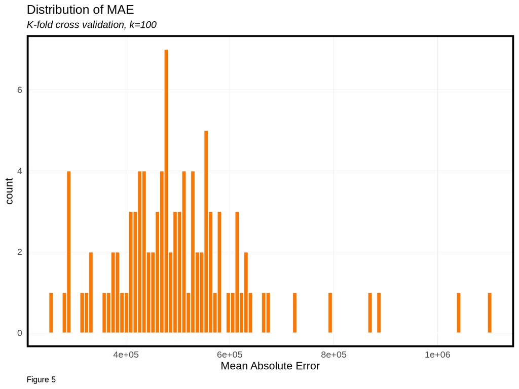

```r
# Distribution of MAE
reg.cv$resample %>%
  ggplot() +
  geom_histogram(aes(x=MAE), bins=100, fill = "#FA7800", color="white") +
  labs(
    title = "Distribution of MAE",
    subtitle = "K-fold cross validation, k=100",
    x = "Mean Absolute Error",
    caption = "Figure 5"
  ) +
  plotTheme()
```

## 5.4 Predicted Price as function of Observed Price

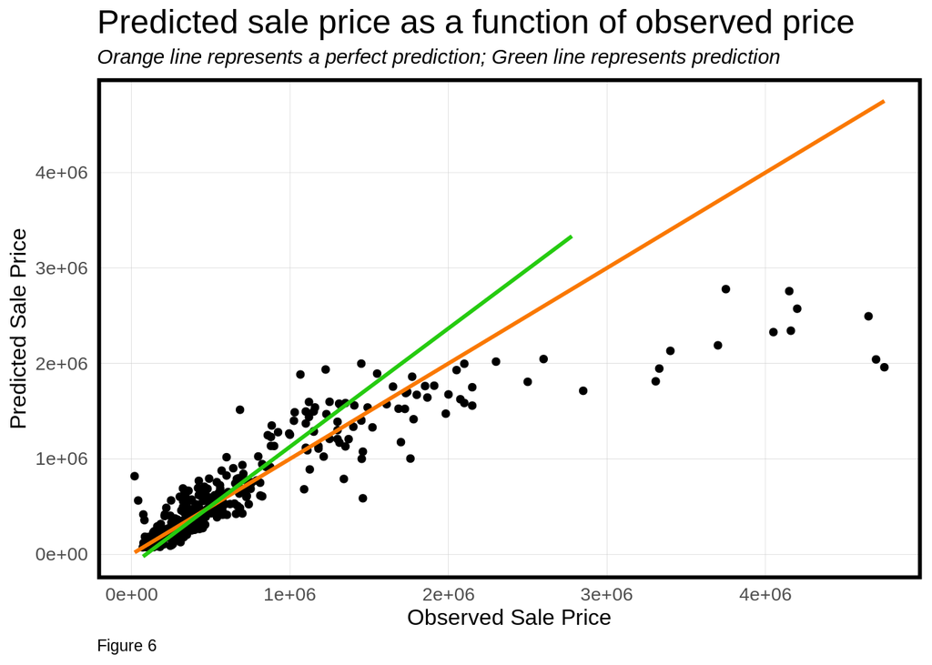

```r
# Plot of predicted price as a function of observed price
miami_errors %>%
  select(SalePrice.Predict, SalePrice) %>%
  ggplot(aes(SalePrice, SalePrice.Predict)) +
  geom_point() +
  stat_smooth(aes(SalePrice, SalePrice),
              method = "lm", se = FALSE, size = 1, colour="#FA7800") +
  stat_smooth(aes(SalePrice.Predict, SalePrice),
              method = "lm", se = FALSE, size = 1, colour="#25CB10") +
  labs(title="Predicted sale price as a function of observed price",
       x = "Observed Sale Price",
       y = "Predicted Sale Price",
       subtitle="Orange line represents a perfect prediction; Green line represents prediction",
       caption="Figure 6") +
  plotTheme() + theme(plot.title = element_text(size = 18, colour = "black"))
```

## 5.5 Map of Residuals

Following from our above discussion, next we see where are the errors spatially distributed. Mapping the residuals (Figure 7) reveals that our model makes substantial errors on houses that either belong in the Miami Beach region or are close to the coastline. We also saw from the map of our sales price that these regions tend to have houses that have high sale prices.

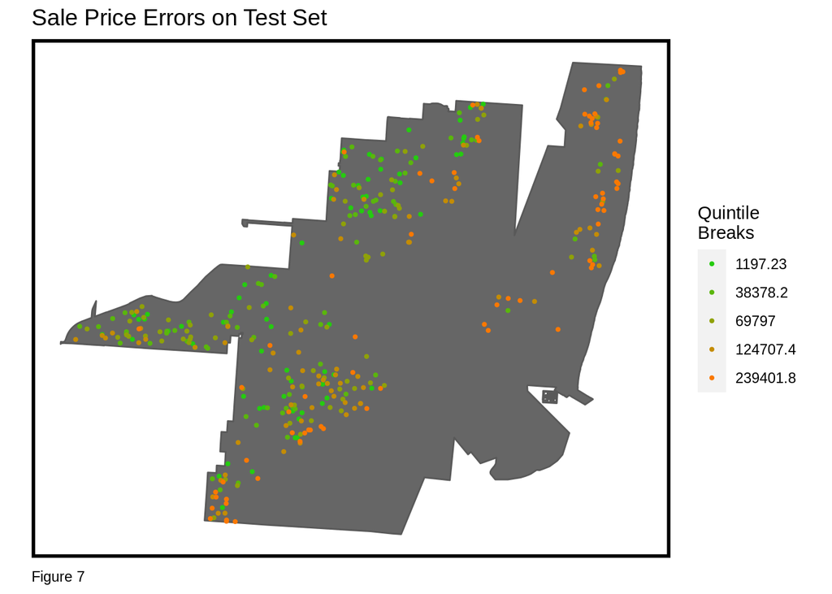

```r
# Map of residuals on test set
miami_errors %>%
  ggplot() +
  geom_sf(data = miami.base, fill = "grey40") +
  geom_sf(data = miami_errors, aes(colour = q5(SalePrice.AbsError)),
          show.legend = "point", size = .75) +
  scale_colour_manual(values = palette5,
                      labels=qBr(miami_errors,"SalePrice.AbsError"),
                      name="Quintile\nBreaks") +
  labs(title="Sale Price Errors on Test Set",
       caption = "Figure 7") +
  mapTheme()
```

## 5.6 Moran’s I test

Next we conduct a Moran’s I test to check whether our model is missing out on some spatial information. The test results in a Moran’s I of 0.153 with a significant p-value indicating that the errors from the current model tend to cluster more that what one would expect due to random chance (Figure 8). This can also be seen from Figure 9 which shows a relation of how errors on neighborhood house relate to errors on the current house. This relation has a correlation significant correlation of 0.27 indicating that the model is missing out on some spatial information.

```r
# Filtering extreme errors that effect plotting
miami.test.filtered <- miami.test %>%
  filter(SalePrice < 1500000)

# Calculating Spatial Lag in Errors
coords.test <-  st_coordinates(miami.test.filtered)

neighborList.test <- knn2nb(knearneigh(coords.test, 5))

spatialWeights.test <- nb2listw(neighborList.test, style="W")

miami.test.filtered$lagPriceError <- lag.listw(spatialWeights.test, miami.test.filtered$SalePrice.Error)

# Moran's I test
moranTest <- moran.mc(miami.test.filtered$SalePrice.Error,
                      spatialWeights.test, nsim = 999)

moranTest
```

```
##
##  Monte-Carlo simulation of Moran I
##
## data:  miami.test.filtered$SalePrice.Error
## weights: spatialWeights.test
## number of simulations + 1: 1000
##
## statistic = 0.15321, observed rank = 1000, p-value = 0.001
## alternative hypothesis: greater
```

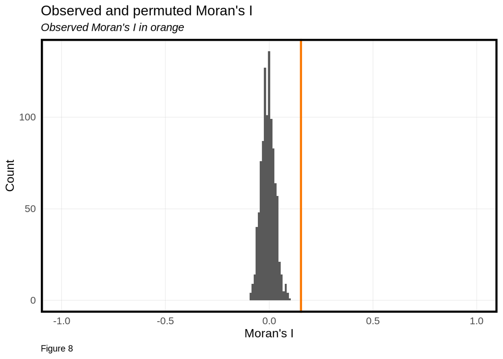

```r
# Plotting
ggplot(as.data.frame(moranTest$res[c(1:999)]), aes(moranTest$res[c(1:999)])) +
  geom_histogram(binwidth = 0.01) +
  geom_vline(aes(xintercept = moranTest$statistic), colour = "#FA7800",size=1) +
  scale_x_continuous(limits = c(-1, 1)) +
  labs(title="Observed and permuted Moran's I",
       subtitle= "Observed Moran's I in orange",
       x="Moran's I",
       y="Count",
       caption = "Figure 8") +
  plotTheme()
```

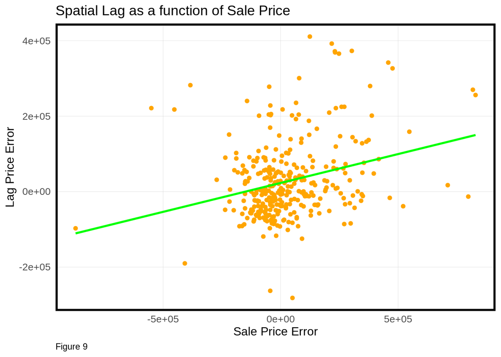

```r
# Plotting error in sale price as a function of spatial lag
miami.test.filtered %>%
  ggplot(aes(x = SalePrice.Error, y = lagPriceError)) +
  geom_point(color = 'orange') +
  geom_smooth(method = "lm", color="green", se=FALSE) +
  labs(
    title = "Spatial Lag as a function of Sale Price",
    x = "Sale Price Error",
    y = "Lag Price Error",
    caption = "Figure 9"
  ) +
  plotTheme()
```

## 5.7 Map of Predicted Values

Next, we make use of our model to get prediction on the entire training set (toPredict = 0) and the secret hold out set (toPredict = 1). Comparing these two plots (Figure 10) to the map of the dependent variable we saw in Figure 3, we can see that our model is good enough in capturing the spatial process of higher prices being associated with houses that are close to the coast line or in the Miami beach region, and as one goes far, the prices tend to go down.

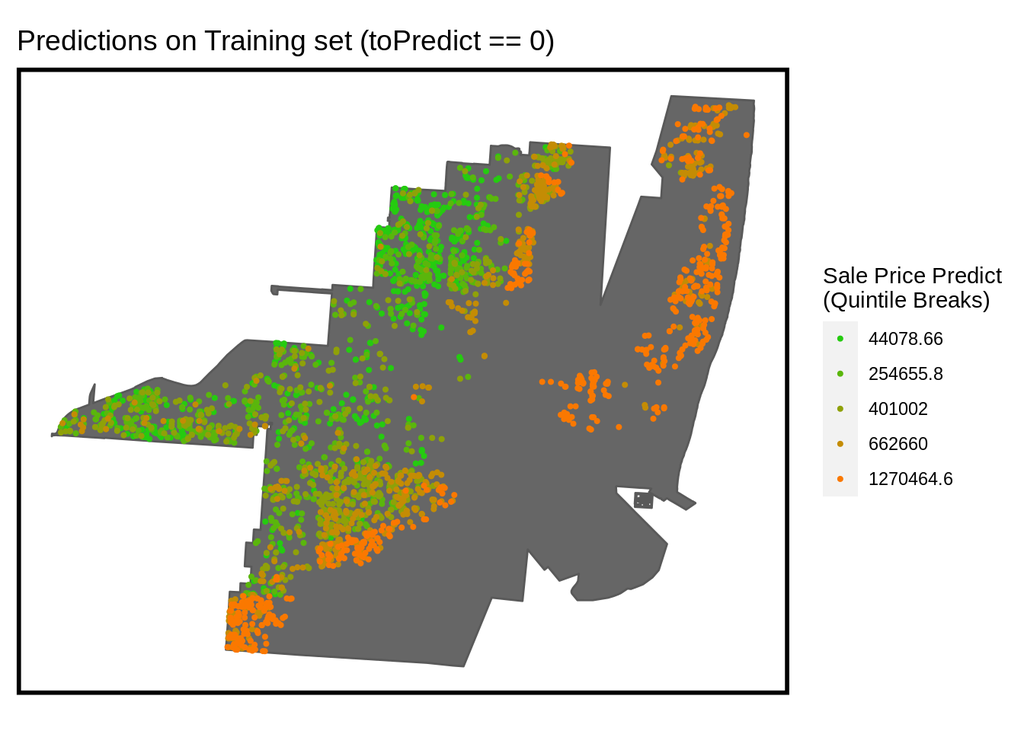

```r
# Calculate prediction on both training and test set
miami_houses_feats.sf <- miami_houses_feats.sf %>%
  mutate(SalePrice.Predict = predict(reg.training, miami_houses_feats.sf))

miami_houses_feats.sf %>%
  filter(toPredict == 0) %>%
  ggplot() +
  geom_sf(data = miami.base, fill = "grey40") +
  geom_sf(aes(colour = q5(SalePrice.Predict)),
          show.legend = "point", size = .75) +
  scale_colour_manual(values = palette5,
                      labels=qBr(miami_houses_feats.sf,"SalePrice.Predict"),
                      name="Sale Price Predict\n(Quintile Breaks)") +
  labs(title="Predictions on Training set (toPredict == 0)") +
  mapTheme()
```

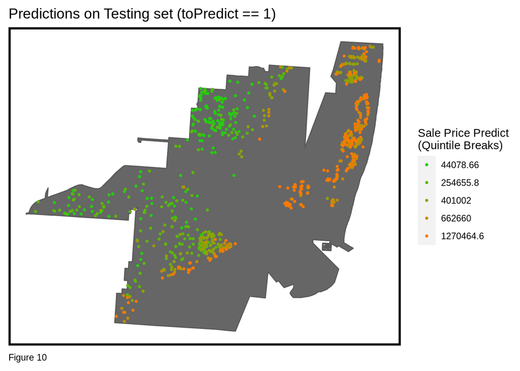

```r
miami_houses_feats.sf %>%
  filter(toPredict == 1) %>%
  ggplot() +
  geom_sf(data = miami.base, fill = "grey40") +
  geom_sf(aes(colour = q5(SalePrice.Predict)),
          show.legend = "point", size = .75) +
  scale_colour_manual(values = palette5,
                      labels=qBr(miami_houses_feats.sf,"SalePrice.Predict"),
                      name="Sale Price Predict\n(Quintile Breaks)") +
  labs(title="Predictions on Testing set (toPredict == 1)",
       caption="Figure 10") +
  mapTheme()
```

## 5.8 Map of MAPE by Neighborhood

Next we look at whether our model generalizes well across neighborhoods. From Figure 11, it can be seen that the model does a fairly decent job in predicting household values across neighborhoods, although there are few neighborhoods like East Little Havana, Santa Clara and Lemon City where the MAPE values are a bit on the higher side. But given that there are very few houses in this region, the estimate of MAPE might not be that reliable.

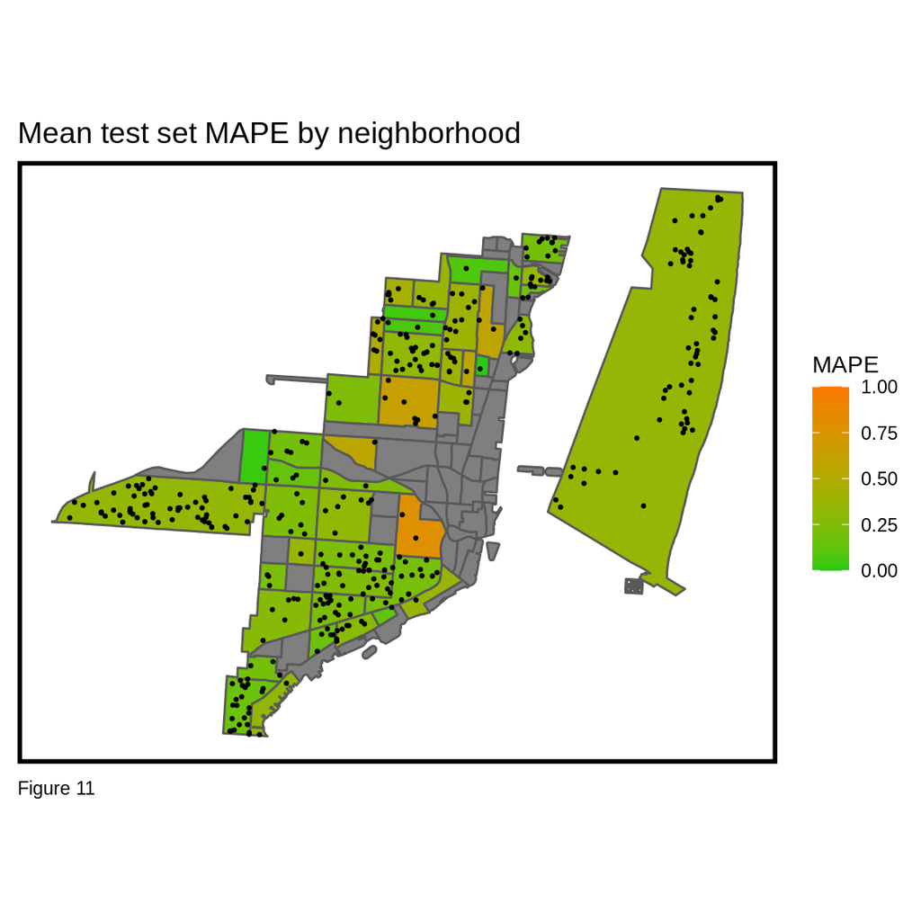

```r
# Map of mean absolute percentage error (MAPE) by neighborhood
st_drop_geometry(miami_errors) %>%
  group_by(nbhood) %>%
  summarize(mean.MAPE = mean(SalePrice.APE, na.rm = T)) %>%
  ungroup() %>%
  right_join(nbhood) %>%
  st_sf() %>%
  ggplot() +
  geom_sf(aes(fill = mean.MAPE)) +
  geom_sf(data = miami_errors, colour = "black", size = .5) +
  scale_fill_gradient(low = palette5[1], high = palette5[5],
                      name = "MAPE", limits = c(0,1)) +
  labs(title = "Mean test set MAPE by neighborhood",
       caption = "Figure 11") +
  mapTheme()
```

## 5.9 MAPE by Neighborhood as Function of Mean Price by Neighborhood

To further extend on the generalizability of the model across neighborhoods, we look at the relation between the mean price of a house in a neighborhood compared to the MAPE of the model in the neighborhood. Ideally, one would expect constant low MAPE across all neighborhood to vouch for the model being generalizable, but from Figure 12, it can be seen that there are some neighborhood, as also discussed in the above section, that have high MAPE values, questioning the generalizability.

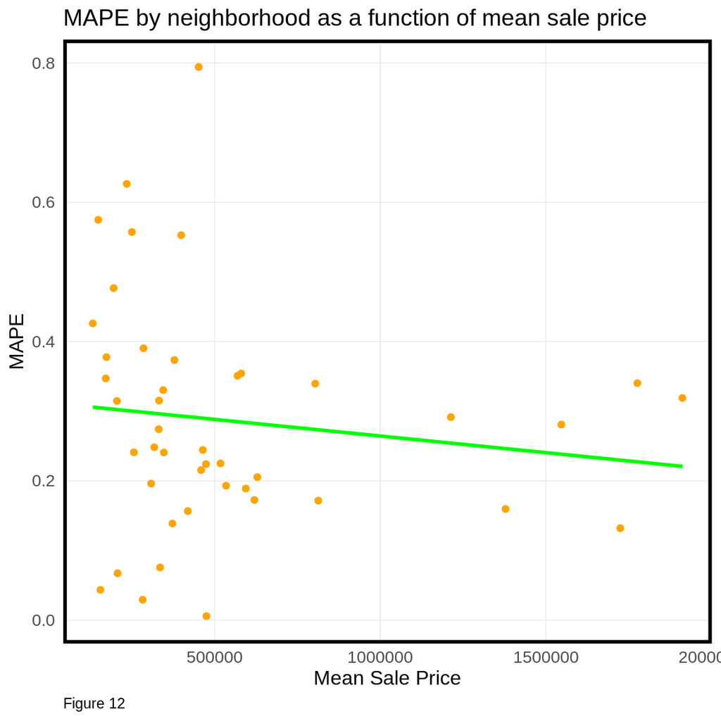

```r
# Scatterplot plot of MAPE by neighborhood as a function of mean price by neighborhood
st_drop_geometry(miami_errors) %>%
  group_by(nbhood) %>%
  summarize(
    MAPE = mean(SalePrice.APE, na.rm = T),
    mean.SalePrice = mean(SalePrice)
    ) %>%
  ggplot(aes(x = mean.SalePrice, y = MAPE)) +
  geom_point(color="orange") +
  geom_smooth(method = "lm", color="green", se=FALSE)+
  labs(
    title = "MAPE by neighborhood as a function of mean sale price",
    x = "Mean Sale Price",
    caption = "Figure 12"
  ) +
  plotTheme()
```

## 5.10 Generalizability by Race and Income

Finally, we look into whether our model is generalizable across different race and income groups in Miami. For this we rely on the census data and label a census tract as being either Majority White or Majority Non-White for race and High Income and Low Income for income as shown in Figure 13. As can be seen in the plot, a crucial spatial process can be seen, with the Non-White population being concentrated in the North while on the other hand it can be seen that the High Income groups are generally situated around the coastline and in the Miami Beach Neighborhood.

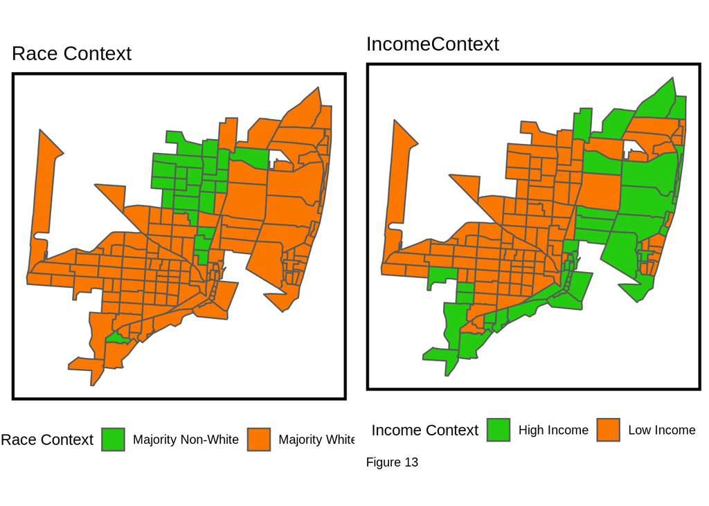

```r
# Download tracts data for Miami and divide the city into two groups (by race or income)
tracts18 <-
  get_acs(geography = "tract", variables = c("B01001_001E","B01001A_001E","B06011_001"),
          year = 2018, state=12, county=086, geometry=T, output = "wide", progress_bar=FALSE) %>%
  st_transform(crs=crs)  %>%
  rename(TotalPop = B01001_001E,
         NumberWhites = B01001A_001E,
         Median_Income = B06011_001E) %>%
  mutate(percentWhite = NumberWhites / TotalPop,
         raceContext = ifelse(percentWhite > .5, "Majority White", "Majority Non-White"),
         incomeContext = ifelse(Median_Income > 29943, "High Income", "Low Income"))

# Only keep tracts that  belong to one of the neighbood
tracts18 <- tracts18[nbhood, ]

# Mapping groups
grid.arrange(ncol = 2,
             ggplot() + geom_sf(data = na.omit(tracts18), aes(fill = raceContext)) +
               scale_fill_manual(values = c("#25CB10", "#FA7800"), name="Race Context") +
               labs(title = "Race Context") +
               mapTheme() + theme(legend.position="bottom"),
             ggplot() + geom_sf(data = na.omit(tracts18), aes(fill = incomeContext)) +
               scale_fill_manual(values = c("#25CB10", "#FA7800"), name="Income Context") +
               labs(title = "IncomeContext", caption="Figure 13") +
               mapTheme() + theme(legend.position="bottom"))
```

```r
# Generalizability across race
st_join(miami_errors, tracts18) %>%
  group_by(raceContext) %>%
  summarize(mean.MAPE = scales::percent(mean(SalePrice.APE, na.rm = T))) %>%
  st_drop_geometry() %>%
  spread(raceContext, mean.MAPE) %>%
  kable() %>%
  kable_styling(bootstrap_options = "striped", full_width = F) %>%
  footnote(general_title = "\n",
           general = "Table 4")
```

| Majority Non-White | Majority White |
| --- | --- |
| 35% | 28% |

Table 4

```r
# Generalizability across income
st_join(miami_errors, tracts18) %>%
  group_by(incomeContext) %>%
  summarize(mean.MAPE = scales::percent(mean(SalePrice.APE, na.rm = T))) %>%
  st_drop_geometry() %>%
  spread(incomeContext, mean.MAPE) %>%
  kable() %>%
  kable_styling(bootstrap_options = "striped", full_width = F) %>%
  footnote(general_title = "\n",
           general = "Table 5")
```

| High Income | Low Income |
| --- | --- |
| 27% | 31% |

Table 5

# 6 Discussion

# 7 Conclusion

Our model did give a respectable performance in predicting the home sales prices. However, before recommending this model to Zillow, we need to work on capturing more spatial processes that might be at play in affecting the prices of highly expensive homes, where our model currently lacks. In addition to this, many more improvements can be made to the model by incorporating census variables like household income, racial groups in neighborhood, percentage of bachelors etc. During the analysis, we did some reasoning to do away with features like presence of tennis court and jacuzzi. More research is required to study whether these features are really required in the model, since they are an important attribute of a luxury home.